# Time Series Regression for Predicting Macroeconomic Indicators - Forecasting of Newly Established Firms in April 2021

Huseyin Sengun - IE360 - Spring 2021

# 1. INTRODUCTION

The aim of this work is to forecast the total number of newly established firms in Turkey at April 2021 with creating and building some models.

Throughout the work, the datasets are taken between January 2013 and March 2021. Additionally, the models are created by using some independent variables that possibly affect the time series data, some seasonality factors and by using special periods such as coup attemp and Covid-19 pandemic.

# 2.Preperation and Manipulation of Data

```r
library(ggplot2)
library(lubridate)
library(readxl)
library(data.table)
library(zoo)
library(forecast)
knitr::opts_chunk$set(echo = TRUE)
```

```r
alldata <- data.table(read_excel("D:/Spring 21 Dersler/IE360/HW3Data.xlsx"))
#all the datas are from 2013-1 to 2021-3.
#In IndProd index and BalanceofPayments data, 2021-3 values are missing. So, I take the mean of 2021-2 and 2020-3 and assigned this value to 2021-3 for these datasets.

# Correcting the types of variable
alldata[,Date:=ym(alldata[,Date])]

head(alldata)
```

```
##          Date NewlyEst IndProdIndex   BOP ComLoanInterest FinConf ExRate
## 1: 2013-01-01     4238     78.17726 -5449         12.0500   181.4   1.76
## 2: 2013-02-01     4310     77.04383 -4707         11.7625   169.9   1.77
## 3: 2013-03-01     4538     85.94448 -4697         11.0580   176.3   1.81
## 4: 2013-04-01     4576     87.07893 -6721         10.6800   174.3   1.80
## 5: 2013-05-01     4475     91.87903 -6276          9.4820   183.4   1.82
## 6: 2013-06-01     4000     91.21805 -3906          9.2575   179.9   1.89
```

[figure not shown]

```r
ggplot(alldata, aes(x = Date, y= NewlyEst)) + geom_line(color="blue") + labs(title = "Total Number of Newly Established Firms in Turkey Between 2013-1 and 2020-3", x = "Date", y= "Newly Established Firms") + geom_point()
```

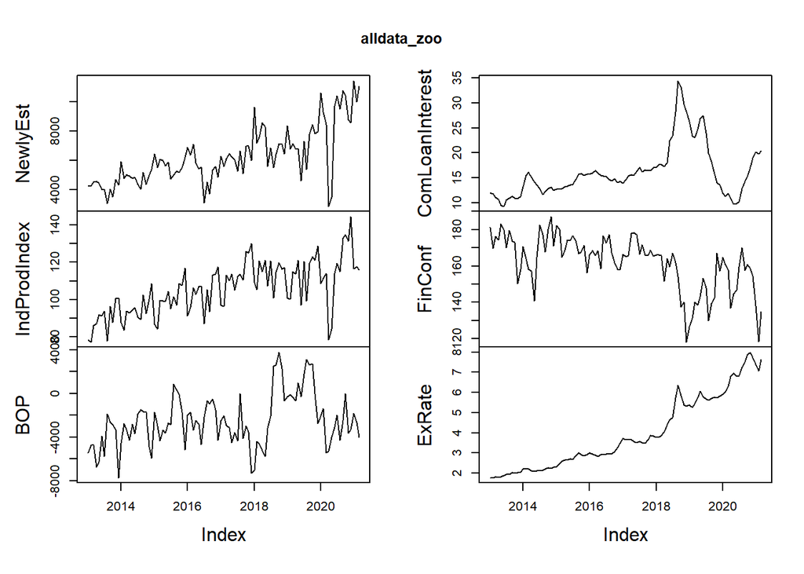

```r
alldata_zoo=zoo(alldata[,list(NewlyEst,IndProdIndex,BOP,ComLoanInterest,FinConf,ExRate)],alldata$Date)
plot(alldata_zoo)
```

```r
str(alldata)
```

```
## Classes 'data.table' and 'data.frame':   99 obs. of  7 variables:
##  $ Date           : Date, format: "2013-01-01" "2013-02-01" ...
##  $ NewlyEst       : num  4238 4310 4538 4576 4475 ...
##  $ IndProdIndex   : num  78.2 77 85.9 87.1 91.9 ...
##  $ BOP            : num  -5449 -4707 -4697 -6721 -6276 ...
##  $ ComLoanInterest: num  12.05 11.76 11.06 10.68 9.48 ...
##  $ FinConf        : num  181 170 176 174 183 ...
##  $ ExRate         : num  1.76 1.77 1.81 1.8 1.82 1.89 1.93 1.95 2.02 1.99 ...
##  - attr(*, ".internal.selfref")=<externalptr>
```

In these graphs, we can see how selected independent variables have changed in time.

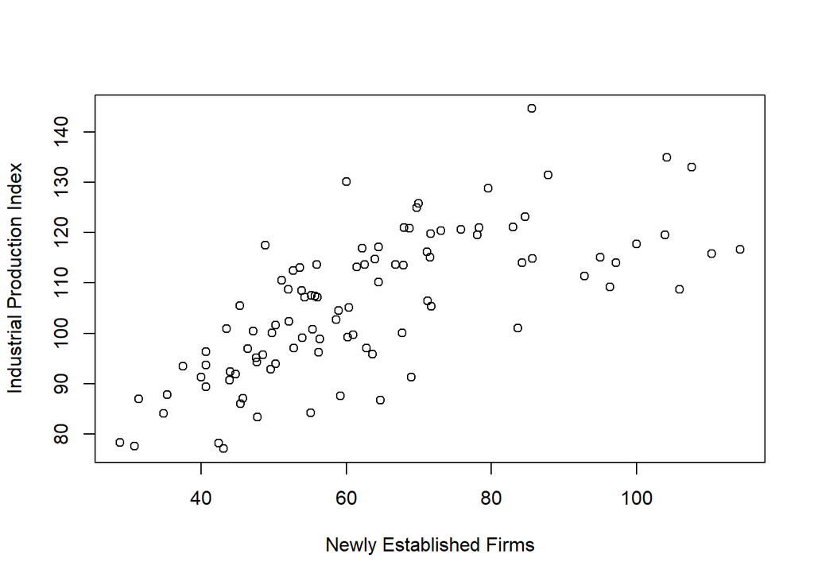

```r
plot(x=alldata$NewlyEst/100, y=alldata$IndProdIndex, xlab = "Newly Established Firms", ylab = "Industrial Production Index")
```

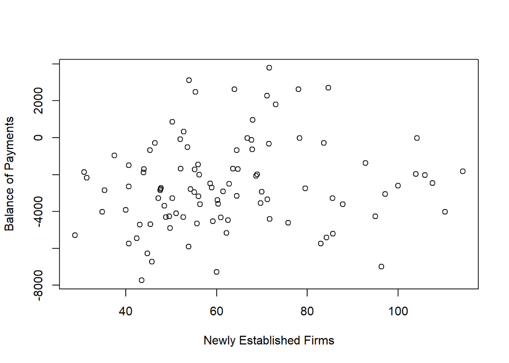

```r
plot(x=alldata$NewlyEst/100, y=alldata$BOP, xlab = "Newly Established Firms", ylab = "Balance of Payments")
```

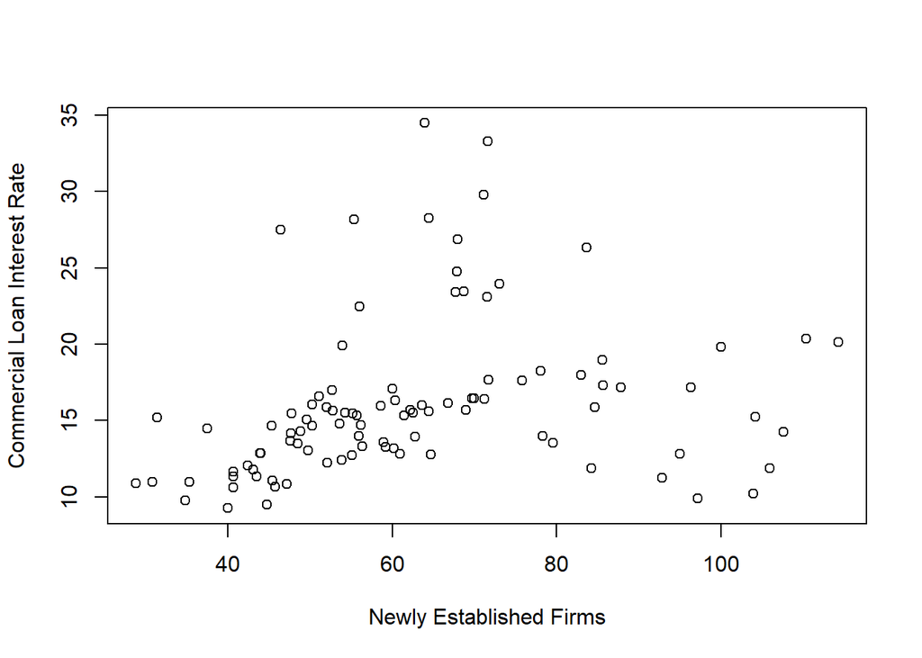

```r
plot(x=alldata$NewlyEst/100, y=alldata$ComLoanInterest, xlab = "Newly Established Firms", ylab = "Commercial Loan Interest Rate")
```

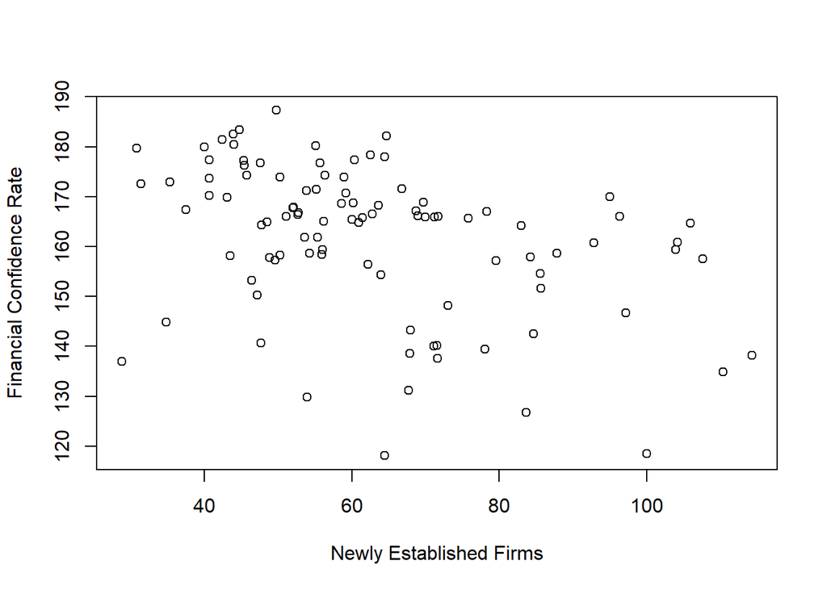

```r
plot(x=alldata$NewlyEst/100, y=alldata$FinConf, xlab = "Newly Established Firms", ylab = "Financial Confidence Rate")
```

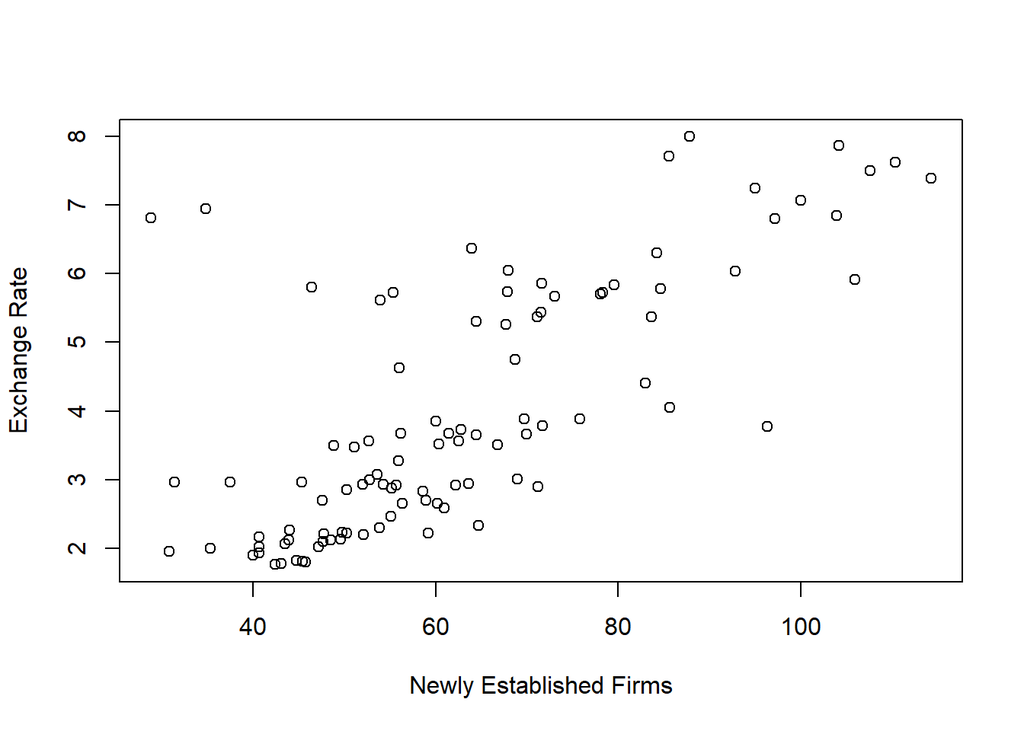

```r
plot(x=alldata$NewlyEst/100, y=alldata$ExRate, xlab = "Newly Established Firms", ylab = "Exchange Rate")
```

In these 5 graphs, we will investigate the possible relationships between the numbers of Newly Established Firms and independent factors. Some of them have some degree of relationship but some of them looks like don’t have relationship.

```r
alldata <- alldata[, Trend:=1:.N]
Month <- seq(1,12)
alldata <- cbind(alldata,Month)
firstmodel<- lm(NewlyEst~ Trend+as.factor(Month), alldata)
alldata <- alldata[,Residual:=0]
alldata$Residual[1] = NA
alldata$Residual[2:99] <- residuals(firstmodel)[1:98]
secondmodel <- lm(NewlyEst~ Trend+as.factor(Month)+Residual, alldata)

summary(firstmodel)
```

```
##
## Call:
## lm(formula = NewlyEst ~ Trend + as.factor(Month), data = alldata)
##
## Residuals:
##     Min      1Q  Median      3Q     Max
## -4977.4  -535.2    80.6   590.1  2625.8
##
## Coefficients:
##                     Estimate Std. Error t value Pr(>|t|)
## (Intercept)         5314.011    460.444  11.541  < 2e-16 ***
## Trend                 49.852      4.326  11.524  < 2e-16 ***
## as.factor(Month)2  -1162.408    578.076  -2.011 0.047477 *
## as.factor(Month)3   -844.371    578.125  -1.461 0.147787
## as.factor(Month)4  -1845.596    595.992  -3.097 0.002642 **
## as.factor(Month)5  -2016.573    595.914  -3.384 0.001078 **
## as.factor(Month)6  -1917.425    595.866  -3.218 0.001822 **
## as.factor(Month)7  -1983.153    595.851  -3.328 0.001288 **
## as.factor(Month)8  -2331.005    595.866  -3.912 0.000182 ***
## as.factor(Month)9  -1812.108    595.914  -3.041 0.003126 **
## as.factor(Month)10 -1465.210    595.992  -2.458 0.015960 *
## as.factor(Month)11 -1519.187    596.102  -2.549 0.012593 *
## as.factor(Month)12 -1782.540    596.243  -2.990 0.003642 **
## ---
## Signif. codes:  0 '***' 0.001 '**' 0.01 '*' 0.05 '.' 0.1 ' ' 1
##
## Residual standard error: 1226 on 86 degrees of freedom
## Multiple R-squared:  0.6506, Adjusted R-squared:  0.6018
## F-statistic: 13.34 on 12 and 86 DF,  p-value: 4.901e-15
```

```r
summary(secondmodel)
```

```
##
## Call:
## lm(formula = NewlyEst ~ Trend + as.factor(Month) + Residual,
##     data = alldata)
##
## Residuals:
##     Min      1Q  Median      3Q     Max
## -4889.3  -464.8    55.0   599.7  3648.0
##
## Coefficients:
##                      Estimate Std. Error t value Pr(>|t|)
## (Intercept)         5.471e+03  4.533e+02  12.071  < 2e-16 ***
## Trend               4.955e+01  4.016e+00  12.338  < 2e-16 ***
## as.factor(Month)2  -1.305e+03  5.443e+02  -2.397 0.018758 *
## as.factor(Month)3  -9.863e+02  5.442e+02  -1.812 0.073494 .
## as.factor(Month)4  -1.903e+03  5.613e+02  -3.390 0.001066 **
## as.factor(Month)5  -2.160e+03  5.607e+02  -3.852 0.000228 ***
## as.factor(Month)6  -2.060e+03  5.604e+02  -3.676 0.000416 ***
## as.factor(Month)7  -2.126e+03  5.603e+02  -3.794 0.000279 ***
## as.factor(Month)8  -2.473e+03  5.601e+02  -4.416 2.98e-05 ***
## as.factor(Month)9  -1.954e+03  5.600e+02  -3.490 0.000773 ***
## as.factor(Month)10 -1.607e+03  5.599e+02  -2.870 0.005190 **
## as.factor(Month)11 -1.661e+03  5.598e+02  -2.966 0.003923 **
## as.factor(Month)12 -1.924e+03  5.597e+02  -3.437 0.000918 ***
## Residual            4.229e-01  9.964e-02   4.244 5.62e-05 ***
## ---
## Signif. codes:  0 '***' 0.001 '**' 0.01 '*' 0.05 '.' 0.1 ' ' 1
##
## Residual standard error: 1119 on 84 degrees of freedom
##   (1 observation deleted due to missingness)
## Multiple R-squared:  0.7123, Adjusted R-squared:  0.6678
## F-statistic:    16 on 13 and 84 DF,  p-value: < 2.2e-16
```

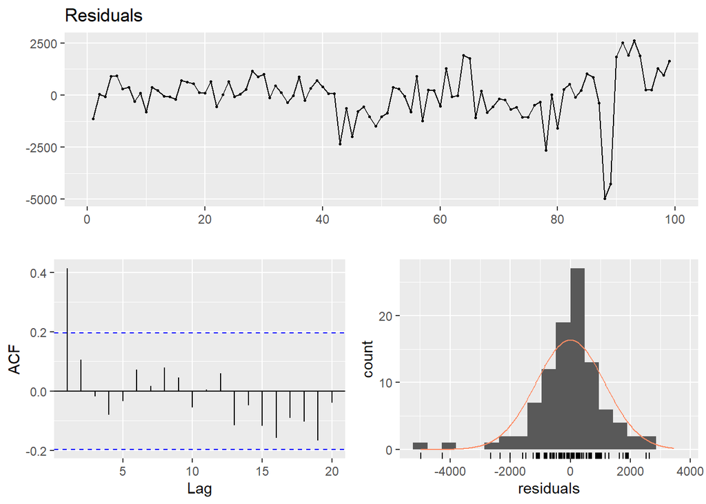

```
##
##  Breusch-Godfrey test for serial correlation of order up to 16
##
## data:  Residuals
## LM test = 30.774, df = 16, p-value = 0.01438
```

```r
checkresiduals(firstmodel)
```

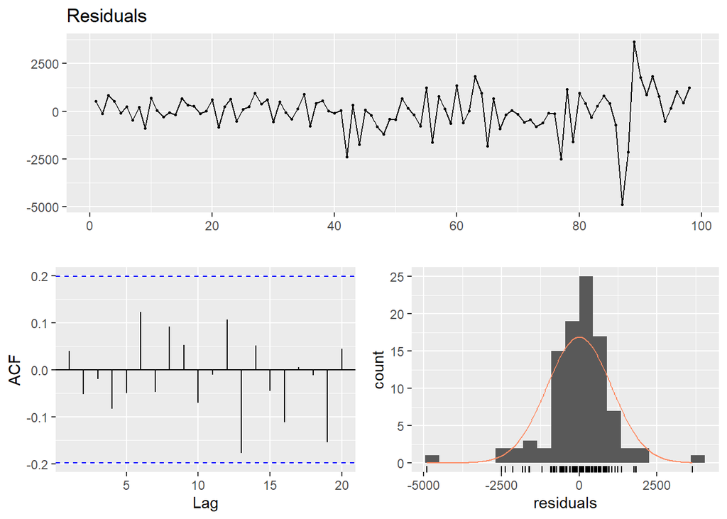

```
##
##  Breusch-Godfrey test for serial correlation of order up to 17
##
## data:  Residuals
## LM test = 15.252, df = 17, p-value = 0.5774
```

```r
checkresiduals(secondmodel)
```

```r
alldata$Residual[1] = 0
```

First, I created a lineer regression model with using Trend and Months. In the second model, I added them Residuals. Second model has better R-Squared and Residual Standard Error values.

```r
alldata$coup <- rep(0,99)
alldata$coup[43:45] <- rep(1,3)

alldata$pandemic <- rep(0,99)
alldata$pandemic[88:89] <- c(1,1)

alldata$Trend <- 1:99

thirdmodel <- lm(NewlyEst ~ Trend + as.factor(Month) + coup + pandemic + Residual, data = alldata)
summary(thirdmodel)
```

```
##
## Call:
## lm(formula = NewlyEst ~ Trend + as.factor(Month) + coup + pandemic +
##     Residual, data = alldata)
##
## Residuals:
##      Min       1Q   Median       3Q      Max
## -2732.12  -469.12    93.81   474.70  2414.71
##
## Coefficients:
##                      Estimate Std. Error t value Pr(>|t|)
## (Intercept)         5.068e+03  3.349e+02  15.131  < 2e-16 ***
## Trend               5.488e+01  3.216e+00  17.066  < 2e-16 ***
## as.factor(Month)2  -1.167e+03  4.180e+02  -2.793 0.006478 **
## as.factor(Month)3  -8.544e+02  4.180e+02  -2.044 0.044113 *
## as.factor(Month)4  -1.171e+03  4.401e+02  -2.662 0.009332 **
## as.factor(Month)5  -1.385e+03  4.408e+02  -3.142 0.002325 **
## as.factor(Month)6  -1.912e+03  4.308e+02  -4.439 2.76e-05 ***
## as.factor(Month)7  -1.776e+03  4.364e+02  -4.070 0.000107 ***
## as.factor(Month)8  -2.129e+03  4.364e+02  -4.878 5.10e-06 ***
## as.factor(Month)9  -1.615e+03  4.364e+02  -3.700 0.000386 ***
## as.factor(Month)10 -1.480e+03  4.309e+02  -3.435 0.000927 ***
## as.factor(Month)11 -1.539e+03  4.310e+02  -3.571 0.000594 ***
## as.factor(Month)12 -1.808e+03  4.311e+02  -4.193 6.85e-05 ***
## coup               -1.658e+03  5.556e+02  -2.985 0.003726 **
## pandemic           -4.970e+03  7.349e+02  -6.763 1.76e-09 ***
## Residual            1.857e-01  8.544e-02   2.173 0.032603 *
## ---
## Signif. codes:  0 '***' 0.001 '**' 0.01 '*' 0.05 '.' 0.1 ' ' 1
##
## Residual standard error: 886.6 on 83 degrees of freedom
## Multiple R-squared:  0.8237, Adjusted R-squared:  0.7919
## F-statistic: 25.86 on 15 and 83 DF,  p-value: < 2.2e-16
```

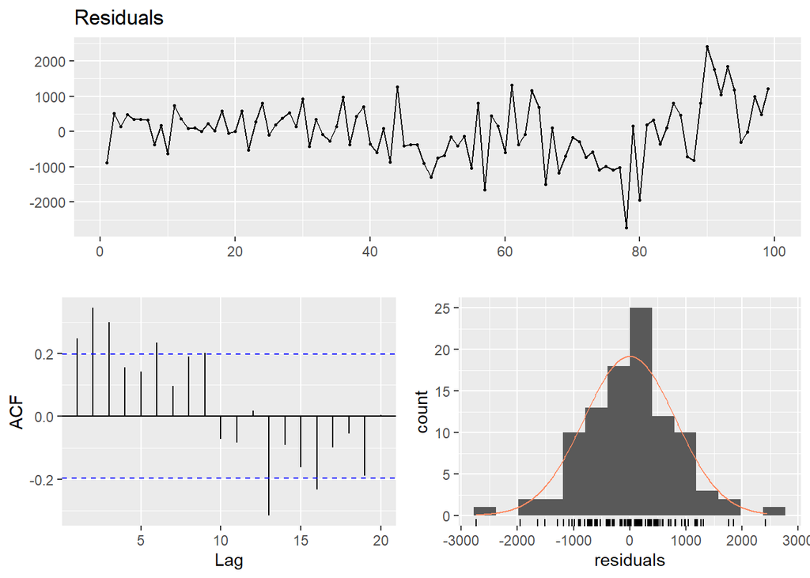

```
##
##  Breusch-Godfrey test for serial correlation of order up to 19
##
## data:  Residuals
## LM test = 57.582, df = 19, p-value = 9.275e-06
```

```r
checkresiduals(thirdmodel)
```

In the third model, I’ve added 2 extraordinary periods which I’ve mentioned at the beginning of the work. Third model has better values than second model but we still don’t use any independent variables.

# 3. Adding Independent Variables

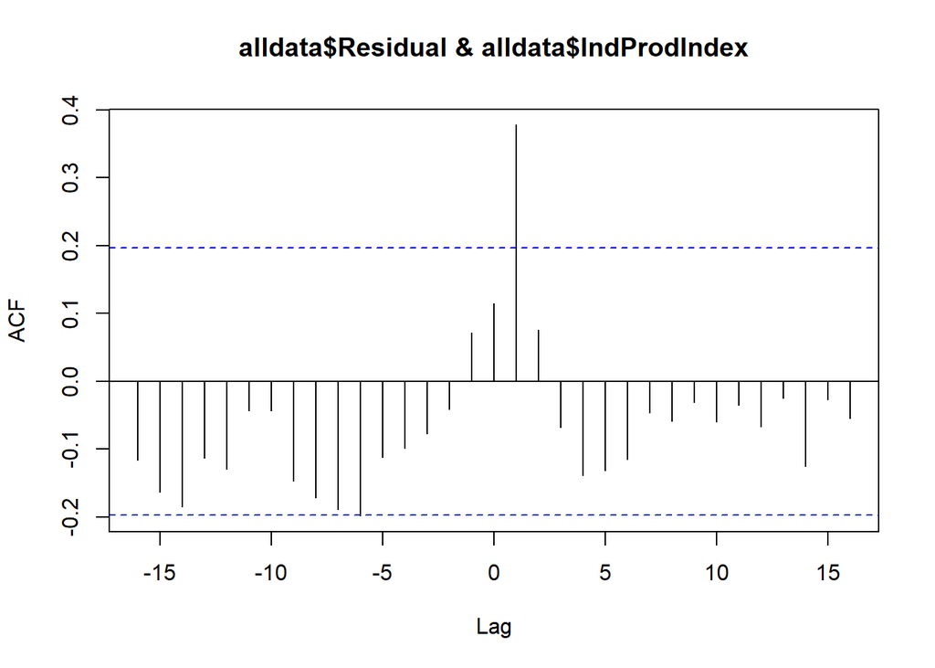

```r
alldata$Residual[1]=0
ccf(alldata$Residual, alldata$IndProdIndex)
```

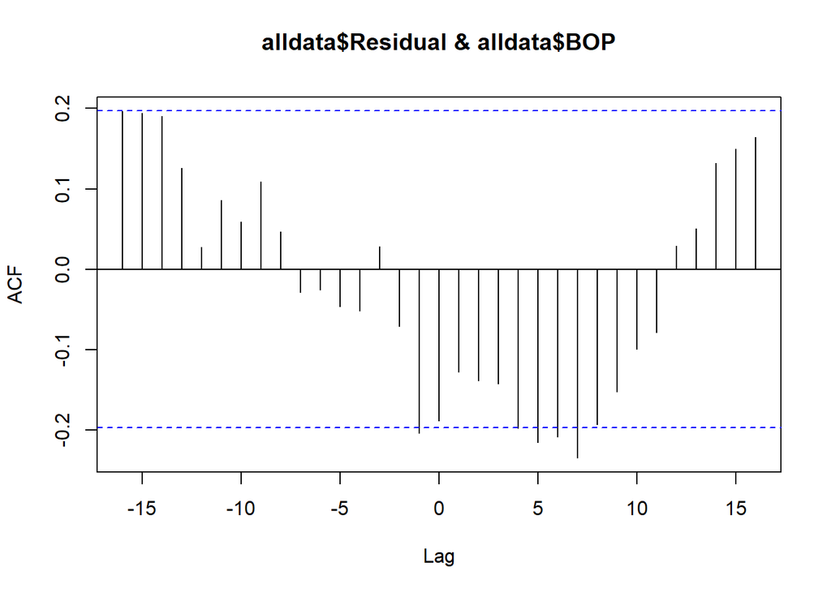

```r
ccf(alldata$Residual, alldata$BOP)
```

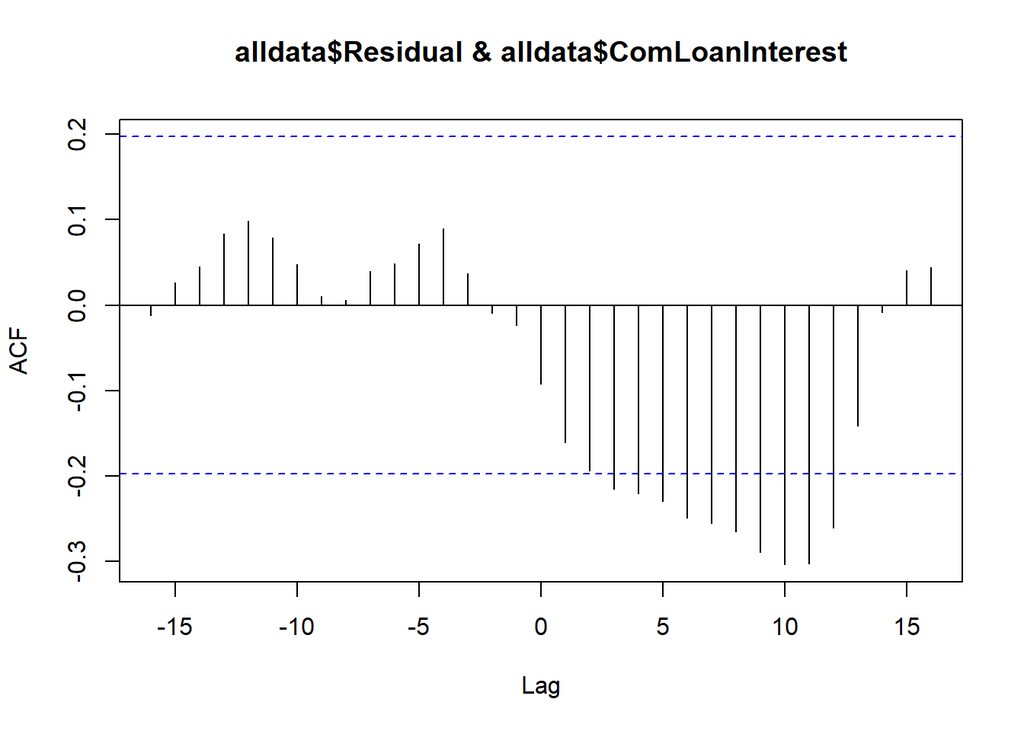

```r
ccf(alldata$Residual, alldata$ComLoanInterest)
```

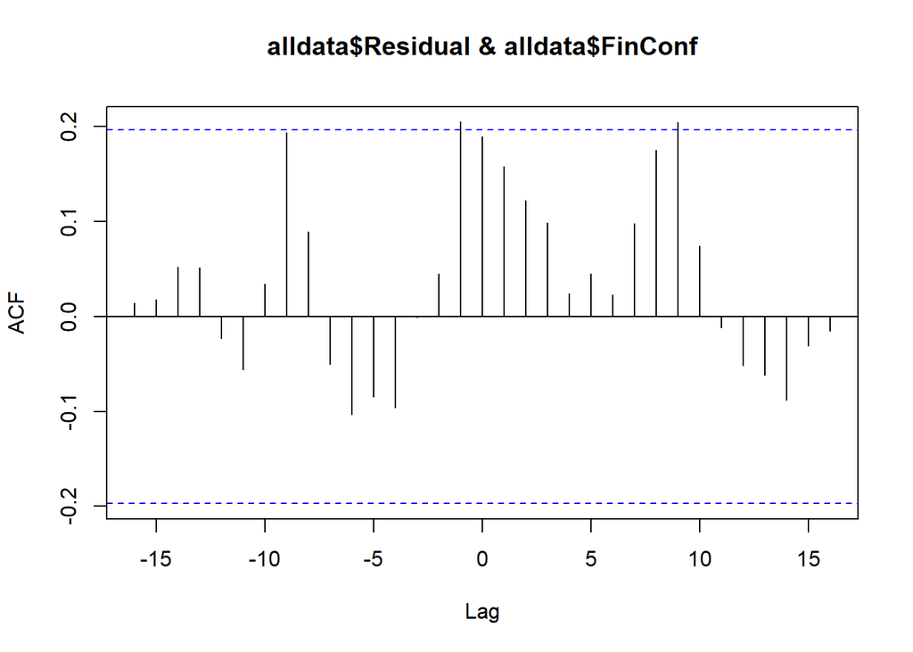

```r
ccf(alldata$Residual, alldata$FinConf)
```

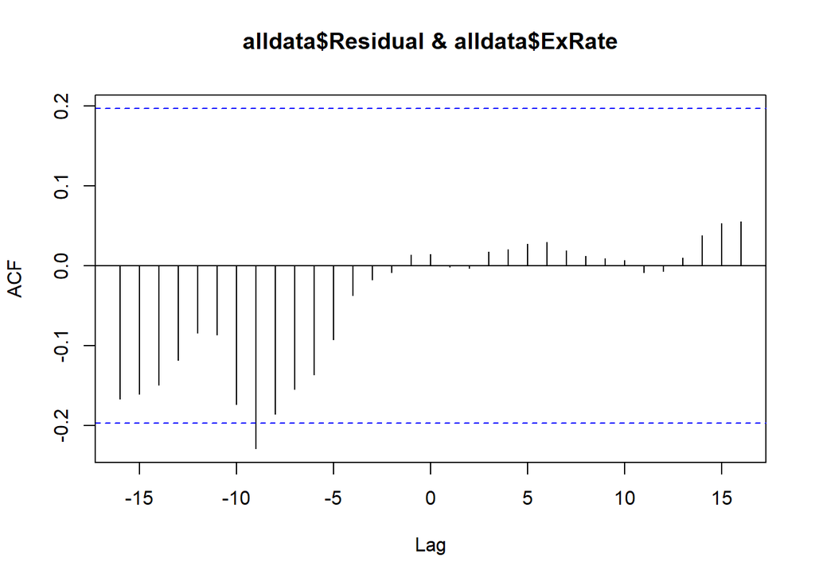

```r
ccf(alldata$Residual, alldata$ExRate)
```

Here I checked the cross correlations.

## 3.1 Industrial Production Index

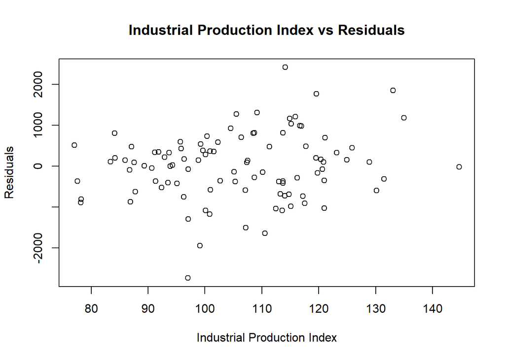

```r
plot(x=alldata$IndProdIndex, y=thirdmodel$residuals, main = "Industrial Production Index vs Residuals", xlab="Industrial Production Index", ylab="Residuals")
```

Looks like positive relationship.

## 3.2 Commercial Loan Interest Rate

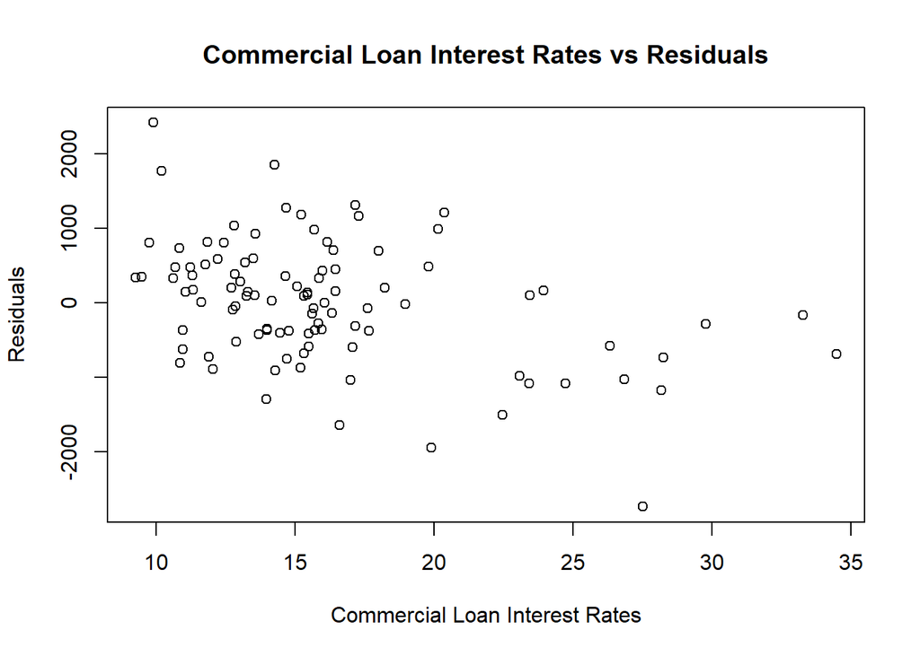

```r
plot(x=alldata$ComLoanInterest, y=thirdmodel$residuals, main = "Commercial Loan Interest Rates vs Residuals", xlab="Commercial Loan Interest Rates", ylab="Residuals")
```

We can talk about a critical level in that graph. Before the %20 interest rate, it looks like usefull but after that point, we can’t talk about a relationship.

## 3.3 Financial Confidence Rate

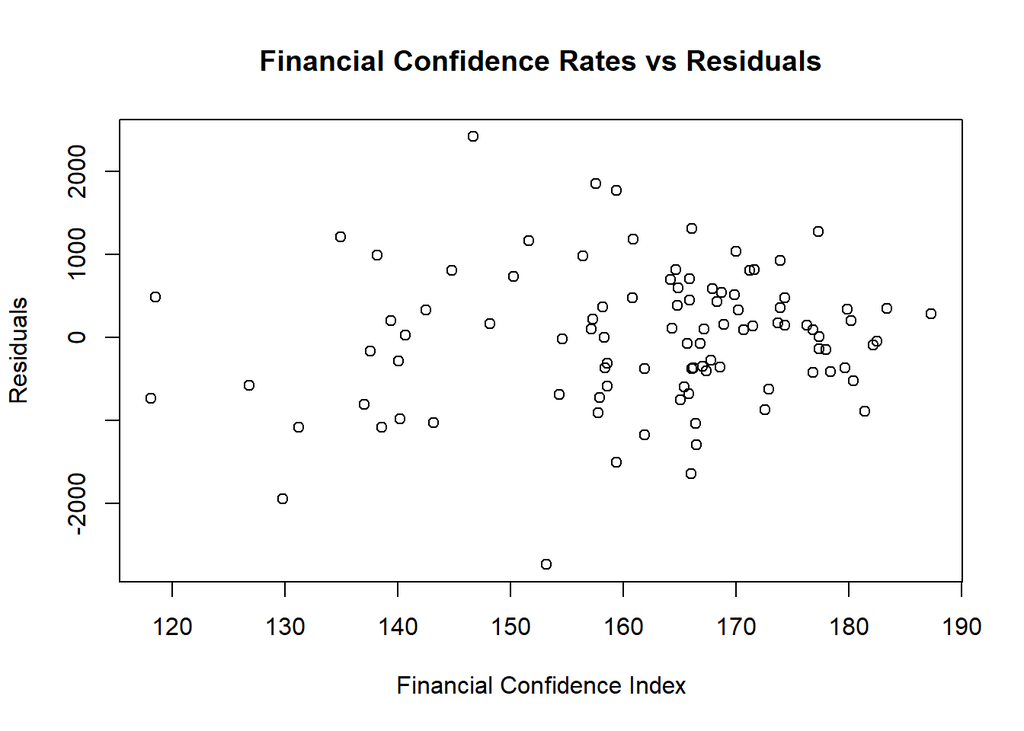

```r
plot(x=alldata$FinConf, y=thirdmodel$residuals, main = "Financial Confidence Rates vs Residuals", xlab="Financial Confidence Index", ylab="Residuals")
```

Looks like some degree of positive relationship. We may use this variable in our model.

## 3.4 Exchange Rate

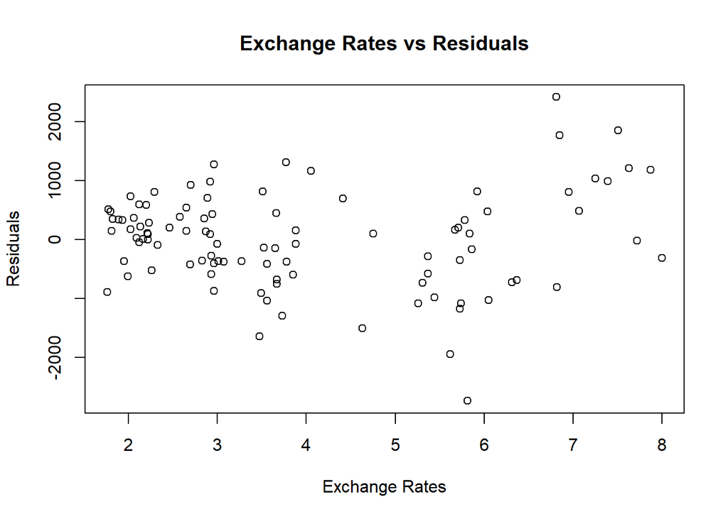

```r
plot(x=alldata$ExRate, y=thirdmodel$residuals, main = "Exchange Rates vs Residuals", xlab="Exchange Rates", ylab="Residuals")
```

Looks like an interesting relationship. However, we won’t use this variable in our model.

## 3.5 Balance of Payments

[figure not shown]

```r
plot(x=alldata$BOP, y=thirdmodel$Residuals, main = "BOP vs Residuals", xlab="BOP", ylab="Residuals")
```

After that point, we will finalize our model with adding related independent variables.

# 4. Creating the Final Model

```r
finalmodel <- lm(NewlyEst ~ Trend + as.factor(Month) + FinConf + IndProdIndex  + coup + pandemic + Residual, data = alldata)
summary(finalmodel)
```

```
##
## Call:
## lm(formula = NewlyEst ~ Trend + as.factor(Month) + FinConf +
##     IndProdIndex + coup + pandemic + Residual, data = alldata)
##
## Residuals:
##      Min       1Q   Median       3Q      Max
## -1585.75  -452.31    32.04   375.24  2815.04
##
## Coefficients:
##                      Estimate Std. Error t value Pr(>|t|)
## (Intercept)        -4.239e+02  1.585e+03  -0.267 0.789848
## Trend               2.892e+01  7.823e+00   3.697 0.000395 ***
## as.factor(Month)2  -1.101e+03  3.781e+02  -2.911 0.004655 **
## as.factor(Month)3  -1.484e+03  4.078e+02  -3.638 0.000482 ***
## as.factor(Month)4  -1.786e+03  4.261e+02  -4.191 7.05e-05 ***
## as.factor(Month)5  -2.265e+03  4.499e+02  -5.035 2.84e-06 ***
## as.factor(Month)6  -2.312e+03  3.982e+02  -5.807 1.20e-07 ***
## as.factor(Month)7  -2.374e+03  4.148e+02  -5.725 1.69e-07 ***
## as.factor(Month)8  -2.382e+03  3.977e+02  -5.989 5.54e-08 ***
## as.factor(Month)9  -2.399e+03  4.350e+02  -5.514 4.06e-07 ***
## as.factor(Month)10 -2.499e+03  4.551e+02  -5.491 4.47e-07 ***
## as.factor(Month)11 -2.617e+03  4.599e+02  -5.691 1.95e-07 ***
## as.factor(Month)12 -3.288e+03  5.314e+02  -6.188 2.37e-08 ***
## FinConf             7.821e-02  8.001e+00   0.010 0.992225
## IndProdIndex        6.933e+01  1.605e+01   4.318 4.42e-05 ***
## coup               -1.077e+03  5.285e+02  -2.038 0.044787 *
## pandemic           -2.013e+03  9.538e+02  -2.110 0.037947 *
## Residual            2.077e-01  8.007e-02   2.594 0.011251 *
## ---
## Signif. codes:  0 '***' 0.001 '**' 0.01 '*' 0.05 '.' 0.1 ' ' 1
##
## Residual standard error: 799.5 on 81 degrees of freedom
## Multiple R-squared:  0.8601, Adjusted R-squared:  0.8307
## F-statistic: 29.29 on 17 and 81 DF,  p-value: < 2.2e-16
```

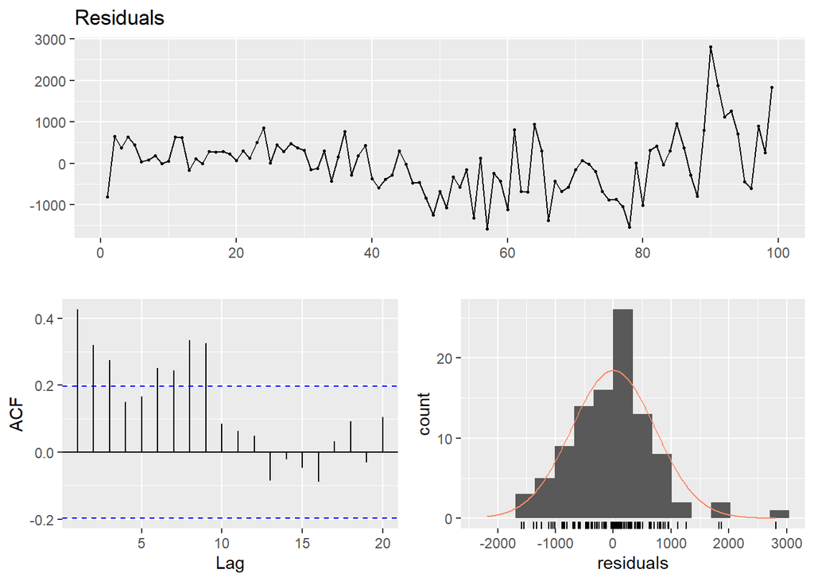

```
##
##  Breusch-Godfrey test for serial correlation of order up to 21
##
## data:  Residuals
## LM test = 59.152, df = 21, p-value = 1.715e-05
```

```r
checkresiduals(finalmodel)
```

We have better values than thirdmodel. But we can still improve it.

# 5. LAG Part

```r
alldata[, Residual:=residuals(finalmodel)]
alldata[, lagvalue:=shift(residuals(finalmodel),1)]

finalmodel2<-lm(NewlyEst ~ Trend+as.factor(Month) + FinConf +IndProdIndex + coup + pandemic + Residual+ lagvalue,alldata)
summary(finalmodel2)
```

```
##
## Call:
## lm(formula = NewlyEst ~ Trend + as.factor(Month) + FinConf +
##     IndProdIndex + coup + pandemic + Residual + lagvalue, data = alldata)
##
## Residuals:
##     Min      1Q  Median      3Q     Max
## -781.76  -84.84   10.38   80.94  338.87
##
## Coefficients:
##                      Estimate Std. Error t value Pr(>|t|)
## (Intercept)        -1.020e+03  3.271e+02  -3.119  0.00253 **
## Trend               3.010e+01  1.626e+00  18.512  < 2e-16 ***
## as.factor(Month)2  -1.098e+03  8.089e+01 -13.569  < 2e-16 ***
## as.factor(Month)3  -1.491e+03  8.683e+01 -17.169  < 2e-16 ***
## as.factor(Month)4  -1.711e+03  9.020e+01 -18.963  < 2e-16 ***
## as.factor(Month)5  -2.213e+03  9.521e+01 -23.246  < 2e-16 ***
## as.factor(Month)6  -2.335e+03  8.501e+01 -27.472  < 2e-16 ***
## as.factor(Month)7  -2.379e+03  8.829e+01 -26.945  < 2e-16 ***
## as.factor(Month)8  -2.384e+03  8.486e+01 -28.092  < 2e-16 ***
## as.factor(Month)9  -2.390e+03  9.228e+01 -25.898  < 2e-16 ***
## as.factor(Month)10 -2.519e+03  9.659e+01 -26.078  < 2e-16 ***
## as.factor(Month)11 -2.643e+03  9.758e+01 -27.085  < 2e-16 ***
## as.factor(Month)12 -3.296e+03  1.123e+02 -29.350  < 2e-16 ***
## FinConf             3.024e+00  1.629e+00   1.857  0.06709 .
## IndProdIndex        7.003e+01  3.386e+00  20.680  < 2e-16 ***
## coup               -1.280e+03  1.075e+02 -11.899  < 2e-16 ***
## pandemic           -2.481e+03  1.908e+02 -13.002  < 2e-16 ***
## Residual            8.946e-01  2.611e-02  34.257  < 2e-16 ***
## lagvalue            2.446e-01  2.781e-02   8.797 2.42e-13 ***
## ---
## Signif. codes:  0 '***' 0.001 '**' 0.01 '*' 0.05 '.' 0.1 ' ' 1
##
## Residual standard error: 165.9 on 79 degrees of freedom
##   (1 observation deleted due to missingness)
## Multiple R-squared:  0.9941, Adjusted R-squared:  0.9927
## F-statistic: 734.6 on 18 and 79 DF,  p-value: < 2.2e-16
```

After taking into consideration of lag, we got better results.

# 6. Forecasting Part

```r
alldata=rbind(alldata, data.table(Date= as.Date("2021-04-01")),fill=T)
alldata[100,trend:=100]

predict(alldata$IndProdIndex)
```

```
##     Point Forecast    Lo 80    Hi 80    Lo 95    Hi 95
## 100       116.7664 102.7801 130.7526 95.37624 138.1565
## 101       116.8959 102.8941 130.8977 95.48197 138.3098
## 102       117.0228 103.0057 131.0398 95.58556 138.4599
## 103       117.1471 103.1151 131.1791 95.68704 138.6072
## 104       117.2690 103.2223 131.3157 95.78642 138.7515
## 105       117.3884 103.3273 131.4495 95.88376 138.8931
## 106       117.5055 103.4301 131.5808 95.97906 139.0318
## 107       117.6202 103.5308 131.7095 96.07238 139.1679
## 108       117.7326 103.6295 131.8357 96.16373 139.3014
## 109       117.8427 103.7261 131.9594 96.25315 139.4323
```

```r
alldata[100, IndProdIndex := 116.7664]

predict(alldata$BOP)
```

```
##     Point Forecast     Lo 80      Hi 80      Lo 95      Hi 95
## 100       -3541.43 -5913.391 -1169.4691  -7169.031   86.17109
## 101       -3541.43 -6426.954  -655.9062  -7954.458  871.59784
## 102       -3541.43 -6862.017  -220.8431  -8619.829 1536.96934
## 103       -3541.43 -7246.338   163.4784  -9207.598 2124.73845
## 104       -3541.43 -7594.379   511.5190  -9739.881 2657.02061
## 105       -3541.43 -7914.809   831.9491 -10229.936 3147.07619
## 106       -3541.43 -8213.313  1130.4534 -10686.459 3603.59905
## 107       -3541.43 -8493.858  1410.9981 -11115.515 4032.65511
## 108       -3541.43 -8759.341  1676.4808 -11521.536 4438.67590
## 109       -3541.43 -9011.955  1929.0949 -11907.876 4825.01580
```

```r
alldata[100, BOP := -3541.43]

predict(alldata$ComLoanInterest)
```

```
##     Point Forecast     Lo 80    Hi 80      Lo 95    Hi 95
## 100       20.69116 18.799987 22.58233 17.7988599 23.58346
## 101       20.95492 17.365930 24.54392 15.4660319 26.44381
## 102       21.16593 15.760757 26.57111 12.8994292 29.43244
## 103       21.33474 14.064285 28.60520 10.2155373 32.45395
## 104       21.46979 12.322703 30.61687  7.4805284 35.45905
## 105       21.57783 10.562930 32.59272  4.7319963 38.42365
## 106       21.66425  8.800225 34.52828  1.9904188 41.33809
## 107       21.73340  7.042569 36.42423 -0.7342872 44.20108
## 108       21.78871  5.293334 38.28409 -3.4387921 47.01622
## 109       21.83297  3.552982 40.11295 -6.1238563 49.78979
```

```r
alldata[100, ComLoanInterest := 20.69116]

predict(alldata$FinConf)
```

```
##     Point Forecast    Lo 80    Hi 80     Lo 95    Hi 95
## 100       132.2379 119.8179 144.6578 113.24320 151.2326
## 101       132.2379 116.9532 147.5226 108.86196 155.6138
## 102       132.2379 114.5464 149.9293 105.18111 159.2946
## 103       132.2379 112.4299 152.0458 101.94425 162.5315
## 104       132.2379 110.5187 153.9570  99.02132 165.4544
## 105       132.2379 108.7626 155.7131  96.33558 168.1402
## 106       132.2379 107.1290 157.3467  93.83722 170.6385
## 107       132.2379 105.5954 158.8803  91.49176 172.9840
## 108       132.2379 104.1454 160.3303  89.27416 175.2016
## 109       132.2379 102.7667 161.7091  87.16553 177.3102
```

```r
alldata[100, FinConf := 132.2379]

predict(alldata$ExRate)
```

```
##     Point Forecast    Lo 80    Hi 80    Lo 95    Hi 95
## 100       7.655753 7.253027 8.058478 7.039838 8.271667
## 101       7.681558 7.110819 8.252298 6.808688 8.554429
## 102       7.707364 7.006860 8.407869 6.636035 8.778694
## 103       7.733170 6.922564 8.543777 6.493455 8.972886
## 104       7.758976 6.850748 8.667205 6.369961 9.147992
## 105       7.784782 6.787736 8.781828 6.259932 9.309633
## 106       7.810588 6.731350 8.889826 6.160036 9.461141
## 107       7.836394 6.680172 8.992616 6.068106 9.604683
## 108       7.862200 6.633222 9.091178 5.982640 9.741760
## 109       7.888006 6.589785 9.186227 5.902549 9.873463
```

```r
alldata[100, ExRate := 7.655753]

predict(alldata$Residual)
```

```
##     Point Forecast      Lo 80    Hi 80     Lo 95    Hi 95
## 100       760.9626  -73.57130 1595.496 -515.3468 2037.272
## 101       760.9626  -96.07021 1617.995 -549.7560 2071.681
## 102       760.9626 -117.99341 1639.919 -583.2846 2105.210
## 103       760.9626 -139.38293 1661.308 -615.9971 2137.922
## 104       760.9626 -160.27596 1682.201 -647.9502 2169.875
## 105       760.9626 -180.70555 1702.631 -679.1945 2201.120
## 106       760.9626 -200.70123 1722.626 -709.7753 2231.700
## 107       760.9626 -220.28952 1742.215 -739.7330 2261.658
## 108       760.9626 -239.49437 1761.420 -769.1043 2291.029
## 109       760.9626 -258.33743 1780.263 -797.9223 2319.847
```

```r
alldata[100, Residual := 829.9922]

predict(alldata$lagvalue)
```

```
##     Point Forecast     Lo 80    Hi 80      Lo 95    Hi 95
## 100       421.6905 -396.7850 1240.166  -830.0597 1673.441
## 101       421.6905 -422.0989 1265.480  -868.7740 1712.155
## 102       421.6905 -446.6752 1290.056  -906.3602 1749.741
## 103       421.6905 -470.5749 1313.956  -942.9116 1786.293
## 104       421.6905 -493.8509 1337.232  -978.5092 1821.890
## 105       421.6905 -516.5496 1359.931 -1013.2239 1856.605
## 106       421.6905 -538.7120 1382.093 -1047.1183 1890.499
## 107       421.6905 -560.3744 1403.755 -1080.2481 1923.629
## 108       421.6905 -581.5691 1424.950 -1112.6627 1956.044
## 109       421.6905 -602.3253 1445.706 -1144.4065 1987.787
```

```r
alldata[100, lagvalue:= 421.6905]

alldata[100,'Trend':=100]
alldata[100,'Month':=4]
alldata[100,'coup':=0]
alldata[100,'pandemic':=0]

head(alldata)
```

```
##          Date NewlyEst IndProdIndex   BOP ComLoanInterest FinConf ExRate Trend
## 1: 2013-01-01     4238     78.17726 -5449         12.0500   181.4   1.76     1
## 2: 2013-02-01     4310     77.04383 -4707         11.7625   169.9   1.77     2
## 3: 2013-03-01     4538     85.94448 -4697         11.0580   176.3   1.81     3
## 4: 2013-04-01     4576     87.07893 -6721         10.6800   174.3   1.80     4
## 5: 2013-05-01     4475     91.87903 -6276          9.4820   183.4   1.82     5
## 6: 2013-06-01     4000     91.21805 -3906          9.2575   179.9   1.89     6
##    Month   Residual coup pandemic  lagvalue trend
## 1:     1 -800.89735    0        0        NA    NA
## 2:     2  656.13784    0        0 -800.8973    NA
## 3:     3  374.56443    0        0  656.1378    NA
## 4:     4  636.21786    0        0  374.5644    NA
## 5:     5  447.08538    0        0  636.2179    NA
## 6:     6   32.03646    0        0  447.0854    NA
```

```r
prediction=predict(finalmodel2,alldata)
prediction[100]
```

```
##     100
## 9702.09
```

My prediction is: 9702.09 We can take it as 9702.

# 7. Conclusion

In this work, I used the time period between January 2013 to March 2021 and tried to create models that explain and predict the Newly Established Companies in Turkey, especially for April 2021.

I chose 5 independent variables at the beginning but in the final model I used just 2 of them since I didn’t find high degree of relation between these independent variables and the number of Newly Established Firms in Turkey. I used Industrial Total Production Index and Financial Services Confidence. I also added the special periods to the model which are beginning of the pandemic and coup attempt in Turkey. In developing my models, I tried to increase the adjusted R square and residual standard error scores.

In the final, I forecasted 9702.09 for April 2021. Probably, there are lots of other factors that affect this result. As we know, there is some degree of total lockdown in Turkey but hopefully, I got close to the real value which will be announced in a short time.